# Exploratory Data Analysis of Aadhaar Enrolment Data

# Top 10 Districts by Enrollment

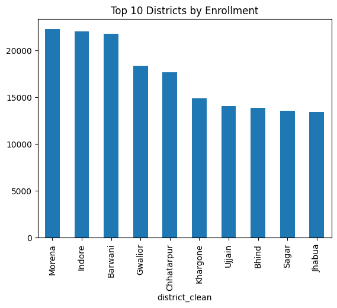

```python
top_districts = df.groupby('district_clean')['total_enrollment'] \
                  .sum().sort_values(ascending=False).head(10)

top_districts.plot(kind='bar')
plt.title('Top 10 Districts by Enrollment')
plt.show()
```

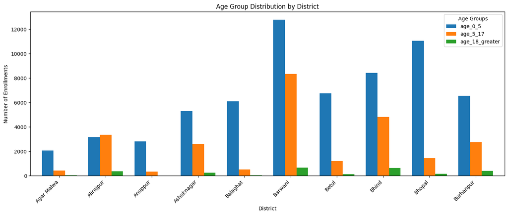

```python
import matplotlib.pyplot as plt

district_age = df.groupby('district_clean')[
    ['age_0_5','age_5_17','age_18_greater']
].sum().head(10)

ax = district_age.plot(
    kind='bar',
    stacked=False,      # important → no overlap
    figsize=(14,6),
    width=0.75
)

plt.title('Age Group Distribution by District')
plt.xlabel('District')
plt.ylabel('Number of Enrollments')
plt.xticks(rotation=45, ha='right')
plt.legend(title='Age Groups')
plt.tight_layout()
plt.show()
```

# 📊 Enrollment Variability Across Districts

This bar chart highlights the top 10 districts with the highest standard  
deviation in total enrollment, indicating significant variability over time.  
High volatility suggests inconsistent enrollment patterns, possibly due to seasonal  
drives, migration, or administrative factors.

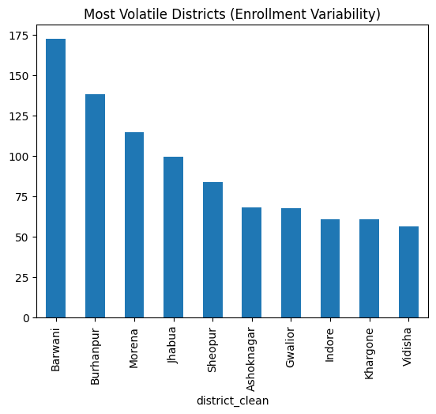

```python
district_std = df.groupby('district_clean')['total_enrollment'].std()

district_std.sort_values(ascending=False).head(10).plot(kind='bar')
plt.title('Most Volatile Districts (Enrollment Variability)')
plt.show()
```

# 📌 District-wise Enrollment Ranking Analysis

This analysis ranks districts based on their total Aadhaar enrollment over the entire study period.

```python
district_rank = df.groupby('district_clean')['total_enrollment'].sum() \
                  .rank(ascending=False)

district_rank.sort_values().head(10)
```

```
district_clean
Morena         1.0
Indore         2.0
Barwani        3.0
Gwalior        4.0
Chhatarpur     5.0
Khargone       6.0
Ujjain         7.0
Bhind          8.0
Sagar          9.0
Jhabua        10.0
Name: total_enrollment, dtype: float64
```

We performed univariate, bivariate, and multivariate analysis to study  
enrollment distribution across states, districts, and age groups.  
Advanced analysis included district-level volatility, age composition,  
time-based trends, and flag-based segmentation to uncover hidden patterns.

# West Bengal

```python
# Extracting rows where state is West Bengal
df_West_Bengal= df[df['state_clean']=='West Bengal']
```

```python
# Total unique districts in West Bengal
df_West_Bengal['district'].nunique()
```

```
58
```

```python
# Same District have more than one spelling so we have to map them
df_West_Bengal['district'].unique()
```

```
array(['Coochbehar', 'Dinajpur Uttar', 'Darjeeling', 'Cooch Behar',
       'North 24 Parganas', 'Uttar Dinajpur', 'Jhargram', 'Nadia',
       'Jalpaiguri', 'Alipurduar', 'Malda', 'Kolkata', 'Dakshin Dinajpur',
       'Kalimpong', 'Birbhum', '24 Paraganas North', 'Medinipur West',
       'Purba Bardhaman', 'Hooghly', '24 Paraganas South', 'Howrah',
       'Dinajpur Dakshin', 'Bankura', 'Barddhaman', 'Bardhaman',
       'Darjiling', 'East Midnapore', 'Haora', 'Koch Bihar', 'Maldah',
       'Murshidabad', 'North Twenty Four Parganas', 'Paschim Bardhaman',
       'Paschim Medinipur', 'Purba Medinipur', 'Purulia', 'Puruliya',
       'South 24 Parganas', 'South Dinajpur',
       'South Twenty Four Parganas', 'West Midnapore', 'Hugli',
       'North Dinajpur', 'HOOGHLY', 'NADIA', 'HOWRAH', 'Hawrah', 'MALDA',
       'hooghly', 'Medinipur', 'East Midnapur', 'nadia', 'Hooghiy',
       'KOLKATA', 'West Medinipur', 'Burdwan', 'South 24 parganas',
       'South 24 Pargana'], dtype=object)
```

```python
df_West_Bengal['district_clean'] = (
    df_West_Bengal['district']
    .str.lower()
    .str.strip()
    .str.replace(r'\*', '', regex=True)
    .str.replace(r'\(.*?\)', '', regex=True)
    .str.replace(r'[^a-z\s]', '', regex=True)
)
```

# Mapping District

```python
## District mapping west Bengal
wb_district_standard_map = {
    "coochbehar": "Cooch Behar",
    "cooch behar": "Cooch Behar",
    "koch bihar": "Cooch Behar",

    "dinajpur uttar": "Uttar Dinajpur",
    "uttar dinajpur": "Uttar Dinajpur",
    "north dinajpur": "Uttar Dinajpur",

    "dinajpur dakshin": "Dakshin Dinajpur",
    "dakshin dinajpur": "Dakshin Dinajpur",
    "south dinajpur": "Dakshin Dinajpur",

    "darjeeling": "Darjeeling",
    "darjiling": "Darjeeling",

    "kalimpong": "Kalimpong",

    "north 24 parganas": "North 24 Parganas",
    "24 paraganas north": "North 24 Parganas",
    "north twenty four parganas": "North 24 Parganas",

    "south 24 parganas": "South 24 Parganas",
    "south 24 pargana": "South 24 Parganas",
    "south 24 parganas": "South 24 Parganas",
    "24 paraganas south": "South 24 Parganas",
    "south twenty four parganas": "South 24 Parganas",

    "nadia": "Nadia",

    "jalpaiguri": "Jalpaiguri",
    "alipurduar": "Alipurduar",

    "malda": "Malda",
    "maldah": "Malda",

    "kolkata": "Kolkata",

    "jhargram": "Jhargram",
    "birbhum": "Birbhum",

    "medinipur west": "Paschim Medinipur",
    "west medinipur": "Paschim Medinipur",
    "west midnapore": "Paschim Medinipur",
    "paschim medinipur": "Paschim Medinipur",
    "medinipur": "Paschim Medinipur",

    "purba medinipur": "Purba Medinipur",
    "east midnapore": "Purba Medinipur",
    "east midnapur": "Purba Medinipur",

    "barddhaman": "Bardhaman",
    "bardhaman": "Bardhaman",
    "burdwan": "Bardhaman",

    "purba bardhaman": "Purba Bardhaman",
    "paschim bardhaman": "Paschim Bardhaman",

    "hooghly": "Hooghly",
    "hugli": "Hooghly",
    "hooghiy": "Hooghly",

    "howrah": "Howrah",
    "haora": "Howrah",
    "hawrah": "Howrah",

    "murshidabad": "Murshidabad",
    "bankura": "Bankura",

    "purulia": "Purulia",
    "puruliya": "Purulia"
}
```

```python
df['district_clean'] = (
df['district']
.apply(clean_name)
.map(wb_district_standard_map)
.fillna(df_West_Bengal['district'])
)
```

```python
## Remaining unmapped
df[df['district_clean'].isna()]['district'].unique()
# count check
df['district_clean'].nunique()
```

```
40
```

```python
df_West_Bengal = df[df['state_clean']=='West Bengal']
df_West_Bengal
```

|  | date | state | district | pincode | age_0_5 | age_5_17 | age_18_greater | year | month | month_name | state_clean | total_enrollment | district_clean |
| --- | --- | --- | --- | --- | --- | --- | --- | --- | --- | --- | --- | --- | --- |
| 30 | 2025-03-09 | West Bengal | Coochbehar | 736135 | 19 | 12 | 19 | 2025 | 3 | Mar | West Bengal | 50 | Cooch Behar |
| 32 | 2025-03-09 | West Bengal | Dinajpur Uttar | 733129 | 26 | 18 | 27 | 2025 | 3 | Mar | West Bengal | 71 | Dinajpur Uttar |
| 173 | 2025-04-01 | West Bengal | Darjeeling | 734010 | 81 | 49 | 17 | 2025 | 4 | Apr | West Bengal | 147 | Darjeeling |
| 199 | 2025-04-01 | West Bengal | Cooch Behar | 736135 | 243 | 127 | 20 | 2025 | 4 | Apr | West Bengal | 390 | Cooch Behar |
| 208 | 2025-04-01 | West Bengal | North 24 Parganas | 700159 | 35 | 28 | 14 | 2025 | 4 | Apr | West Bengal | 77 | North 24 Parganas |
| ... | ... | ... | ... | ... | ... | ... | ... | ... | ... | ... | ... | ... | ... |
| 1006024 | 2025-12-31 | West Bengal | West Midnapore | 721149 | 2 | 0 | 0 | 2025 | 12 | Dec | West Bengal | 2 | West Midnapore |
| 1006025 | 2025-12-31 | West Bengal | West Midnapore | 721150 | 2 | 2 | 0 | 2025 | 12 | Dec | West Bengal | 4 | West Midnapore |
| 1006026 | 2025-12-31 | West Bengal | West Midnapore | 721305 | 0 | 1 | 0 | 2025 | 12 | Dec | West Bengal | 1 | West Midnapore |
| 1006027 | 2025-12-31 | West Bengal | West Midnapore | 721504 | 1 | 0 | 0 | 2025 | 12 | Dec | West Bengal | 1 | West Midnapore |
| 1006028 | 2025-12-31 | West Bengal | West Midnapore | 721517 | 2 | 1 | 0 | 2025 | 12 | Dec | West Bengal | 3 | West Midnapore |

75371 rows × 13 columns

```python
#Check West Bengal-specific unmapped districts
df_West_Bengal_unmapped = df_West_Bengal[df_West_Bengal['district_clean'].isna()]
print(f"Unmapped West Bengal districts count: {len(df_West_Bengal_unmapped)}")
df_West_Bengal_unmapped['district'].unique()
```

```
Unmapped West Bengal districts count: 0
```

```
array([], dtype=object)
```

```python
# Final unique districts in West Bengal after cleaning
df_West_Bengal['district_clean'].unique()
```

```
array(['Cooch Behar', 'Dinajpur Uttar', 'Darjeeling', 'North 24 Parganas',
       'Uttar Dinajpur', 'Jhargram', 'Nadia', 'Jalpaiguri', 'Alipurduar',
       'Malda', 'Kolkata', 'Dakshin Dinajpur', 'Kalimpong', 'Birbhum',
       '24 Paraganas North', 'Medinipur West', 'Purba Bardhaman',
       'Hooghly', '24 Paraganas South', 'Howrah', 'Dinajpur Dakshin',
       'Bankura', 'Bardhaman', 'East Midnapore', 'Koch Bihar',
       'Murshidabad', 'North Twenty Four Parganas', 'Paschim Bardhaman',
       'Paschim Medinipur', 'Purba Medinipur', 'Purulia',
       'South 24 Parganas', 'South Dinajpur',
       'South Twenty Four Parganas', 'West Midnapore', 'North Dinajpur',
       'East Midnapur', 'West Medinipur', 'South 24 parganas',
       'South 24 Pargana'], dtype=object)
```

```python
df_West_Bengal['total_enrollment'] = (
    df_West_Bengal['age_0_5'] +
    df_West_Bengal['age_5_17'] +
    df_West_Bengal['age_18_greater']
)
```

```python
# Total unique districts in West Bengal after cleaning
df_West_Bengal['district_clean'].nunique()
```

```
40
```

```python
# unique pincodes in West Bengal
df_West_Bengal['pincode'].nunique()
```

```
1336
```

```python
# Check unique pincodes per district in West Bengal
pincode_check = df_West_Bengal.groupby('district_clean')['pincode'].nunique().reset_index()
pincode_check
```

|  | district_clean | pincode |
| --- | --- | --- |
| 0 | 24 Paraganas North | 23 |
| 1 | 24 Paraganas South | 1 |
| 2 | Alipurduar | 25 |
| 3 | Bankura | 74 |
| 4 | Bardhaman | 167 |
| 5 | Birbhum | 49 |
| 6 | Cooch Behar | 45 |
| 7 | Dakshin Dinajpur | 27 |
| 8 | Darjeeling | 64 |
| 9 | Dinajpur Dakshin | 2 |
| 10 | Dinajpur Uttar | 6 |
| 11 | East Midnapore | 77 |
| 12 | East Midnapur | 1 |
| 13 | Hooghly | 106 |
| 14 | Howrah | 59 |
| 15 | Jalpaiguri | 71 |
| 16 | Jhargram | 46 |
| 17 | Kalimpong | 17 |
| 18 | Koch Bihar | 39 |
| 19 | Kolkata | 94 |
| 20 | Malda | 39 |
| 21 | Medinipur West | 2 |
| 22 | Murshidabad | 98 |
| 23 | Nadia | 79 |
| 24 | North 24 Parganas | 150 |
| 25 | North Dinajpur | 15 |
| 26 | North Twenty Four Parganas | 96 |
| 27 | Paschim Bardhaman | 83 |
| 28 | Paschim Medinipur | 95 |
| 29 | Purba Bardhaman | 91 |
| 30 | Purba Medinipur | 103 |
| 31 | Purulia | 43 |
| 32 | South 24 Pargana | 1 |
| 33 | South 24 Parganas | 92 |
| 34 | South 24 parganas | 1 |
| 35 | South Dinajpur | 20 |
| 36 | South Twenty Four Parganas | 64 |
| 37 | Uttar Dinajpur | 25 |
| 38 | West Medinipur | 1 |
| 39 | West Midnapore | 61 |

```python
# Pincode associated with multiple districts in Bihar
pin_district_count = (
    df_West_Bengal.groupby('pincode')['district_clean']
    .nunique()
    .reset_index(name='district_count')
)
```

```python
pin_district_count
```

|  | pincode | district_count |
| --- | --- | --- |
| 0 | 700001 | 1 |
| 1 | 700002 | 1 |
| 2 | 700003 | 1 |
| 3 | 700004 | 1 |
| 4 | 700005 | 1 |
| ... | ... | ... |
| 1331 | 743702 | 1 |
| 1332 | 743704 | 2 |
| 1333 | 743710 | 2 |
| 1334 | 743711 | 3 |
| 1335 | 756084 | 1 |

1336 rows × 2 columns

```python
# Extract problematic pincodes (associated with >1 district)
problem_pins = pin_district_count[
pin_district_count['district_count'] > 1
]
```

```python
problem_pins
```

|  | pincode | district_count |
| --- | --- | --- |
| 7 | 700008 | 3 |
| 17 | 700018 | 2 |
| 23 | 700024 | 2 |
| 27 | 700028 | 2 |
| 29 | 700030 | 3 |
| ... | ... | ... |
| 1328 | 743613 | 2 |
| 1330 | 743701 | 2 |
| 1332 | 743704 | 2 |
| 1333 | 743710 | 2 |
| 1334 | 743711 | 3 |

634 rows × 2 columns

```python
# Get all records with problematic pincodes(flagged records)
df_flagged = df_West_Bengal.merge(
problem_pins[['pincode']],
on='pincode',
how='inner'
)
```

```python
df_flagged
```

|  | date | state | district | pincode | age_0_5 | age_5_17 | age_18_greater | year | month | month_name | state_clean | total_enrollment | district_clean |
| --- | --- | --- | --- | --- | --- | --- | --- | --- | --- | --- | --- | --- | --- |
| 0 | 2025-03-09 | West Bengal | Coochbehar | 736135 | 19 | 12 | 19 | 2025 | 3 | Mar | West Bengal | 50 | Cooch Behar |
| 1 | 2025-03-09 | West Bengal | Dinajpur Uttar | 733129 | 26 | 18 | 27 | 2025 | 3 | Mar | West Bengal | 71 | Dinajpur Uttar |
| 2 | 2025-04-01 | West Bengal | Cooch Behar | 736135 | 243 | 127 | 20 | 2025 | 4 | Apr | West Bengal | 390 | Cooch Behar |
| 3 | 2025-04-01 | West Bengal | North 24 Parganas | 700159 | 35 | 28 | 14 | 2025 | 4 | Apr | West Bengal | 77 | North 24 Parganas |
| 4 | 2025-04-01 | West Bengal | Uttar Dinajpur | 733134 | 484 | 109 | 27 | 2025 | 4 | Apr | West Bengal | 620 | Uttar Dinajpur |
| ... | ... | ... | ... | ... | ... | ... | ... | ... | ... | ... | ... | ... | ... |
| 44031 | 2025-12-31 | West Bengal | West Midnapore | 721149 | 2 | 0 | 0 | 2025 | 12 | Dec | West Bengal | 2 | West Midnapore |
| 44032 | 2025-12-31 | West Bengal | West Midnapore | 721150 | 2 | 2 | 0 | 2025 | 12 | Dec | West Bengal | 4 | West Midnapore |
| 44033 | 2025-12-31 | West Bengal | West Midnapore | 721305 | 0 | 1 | 0 | 2025 | 12 | Dec | West Bengal | 1 | West Midnapore |
| 44034 | 2025-12-31 | West Bengal | West Midnapore | 721504 | 1 | 0 | 0 | 2025 | 12 | Dec | West Bengal | 1 | West Midnapore |
| 44035 | 2025-12-31 | West Bengal | West Midnapore | 721517 | 2 | 1 | 0 | 2025 | 12 | Dec | West Bengal | 3 | West Midnapore |

44036 rows × 13 columns

```python
# Summary of flagged records by district and pincode(for review)
flagged_pincode=df_flagged.groupby(['district_clean','pincode'])[['age_0_5','age_5_17','age_18_greater']].sum().reset_index()
# flagged_pincode.to_excel('flagged_pincode_domain.xlsx')
```

```python
# Add total enrollment column to flagged_pincode
flagged_pincode['total_enrollment']=flagged_pincode['age_0_5']+flagged_pincode['age_5_17']+flagged_pincode['age_18_greater']
flagged_pincode
```

|  | district_clean | pincode | age_0_5 | age_5_17 | age_18_greater | total_enrollment |
| --- | --- | --- | --- | --- | --- | --- |
| 0 | 24 Paraganas North | 700049 | 55 | 67 | 12 | 134 |
| 1 | 24 Paraganas North | 700056 | 34 | 53 | 11 | 98 |
| 2 | 24 Paraganas North | 700102 | 76 | 67 | 14 | 157 |
| 3 | 24 Paraganas North | 700110 | 114 | 127 | 25 | 266 |
| 4 | 24 Paraganas North | 700119 | 116 | 132 | 13 | 261 |
| ... | ... | ... | ... | ... | ... | ... |
| 1445 | West Midnapore | 721513 | 20 | 8 | 1 | 29 |
| 1446 | West Midnapore | 721515 | 1 | 0 | 0 | 1 |
| 1447 | West Midnapore | 721516 | 3 | 0 | 0 | 3 |
| 1448 | West Midnapore | 721517 | 52 | 11 | 0 | 63 |
| 1449 | West Midnapore | 721641 | 3 | 0 | 0 | 3 |

1450 rows × 6 columns

```python
idx = flagged_pincode.groupby('pincode')['total_enrollment'].idxmax()
df_filtered = flagged_pincode.loc[idx]
df_filtered
```

|  | district_clean | pincode | age_0_5 | age_5_17 | age_18_greater | total_enrollment |
| --- | --- | --- | --- | --- | --- | --- |
| 1211 | South 24 Parganas | 700008 | 29 | 29 | 0 | 58 |
| 573 | Kolkata | 700018 | 167 | 258 | 9 | 434 |
| 574 | Kolkata | 700024 | 290 | 285 | 9 | 584 |
| 639 | North 24 Parganas | 700028 | 86 | 38 | 7 | 131 |
| 640 | North 24 Parganas | 700030 | 22 | 20 | 2 | 44 |
| ... | ... | ... | ... | ... | ... | ... |
| 1286 | South 24 Parganas | 743613 | 37 | 13 | 0 | 50 |
| 753 | North 24 Parganas | 743701 | 100 | 15 | 2 | 117 |
| 754 | North 24 Parganas | 743704 | 183 | 40 | 12 | 235 |
| 755 | North 24 Parganas | 743710 | 191 | 35 | 14 | 240 |
| 756 | North 24 Parganas | 743711 | 287 | 53 | 3 | 343 |

634 rows × 6 columns

```python
# Creating a flag for pincodes associated with multiple districts
df_West_Bengal['pin_multi_district_flag']=(
df_West_Bengal.groupby('pincode')['district_clean']
.transform('nunique')>1
)
```

```python
# Creating a flag for pincodes associated with multiple districts
pin_district_map= (
    df_West_Bengal[df_West_Bengal['pin_multi_district_flag']]
    .groupby('pincode')['district_clean']  # noqa: SC100
    .unique()
    .reset_index()
)
```

```python
## monthly enrolment check
df_West_Bengal['month'] = df_West_Bengal['date'].dt.month.astype(str).str.zfill(2)
df_West_Bengal
```

|  | date | state | district | pincode | age_0_5 | age_5_17 | age_18_greater | year | month | month_name | state_clean | total_enrollment | district_clean | pin_multi_district_flag |
| --- | --- | --- | --- | --- | --- | --- | --- | --- | --- | --- | --- | --- | --- | --- |
| 30 | 2025-03-09 | West Bengal | Coochbehar | 736135 | 19 | 12 | 19 | 2025 | 03 | Mar | West Bengal | 50 | Cooch Behar | True |
| 32 | 2025-03-09 | West Bengal | Dinajpur Uttar | 733129 | 26 | 18 | 27 | 2025 | 03 | Mar | West Bengal | 71 | Dinajpur Uttar | True |
| 173 | 2025-04-01 | West Bengal | Darjeeling | 734010 | 81 | 49 | 17 | 2025 | 04 | Apr | West Bengal | 147 | Darjeeling | False |
| 199 | 2025-04-01 | West Bengal | Cooch Behar | 736135 | 243 | 127 | 20 | 2025 | 04 | Apr | West Bengal | 390 | Cooch Behar | True |
| 208 | 2025-04-01 | West Bengal | North 24 Parganas | 700159 | 35 | 28 | 14 | 2025 | 04 | Apr | West Bengal | 77 | North 24 Parganas | True |
| ... | ... | ... | ... | ... | ... | ... | ... | ... | ... | ... | ... | ... | ... | ... |
| 1006024 | 2025-12-31 | West Bengal | West Midnapore | 721149 | 2 | 0 | 0 | 2025 | 12 | Dec | West Bengal | 2 | West Midnapore | True |
| 1006025 | 2025-12-31 | West Bengal | West Midnapore | 721150 | 2 | 2 | 0 | 2025 | 12 | Dec | West Bengal | 4 | West Midnapore | True |
| 1006026 | 2025-12-31 | West Bengal | West Midnapore | 721305 | 0 | 1 | 0 | 2025 | 12 | Dec | West Bengal | 1 | West Midnapore | True |
| 1006027 | 2025-12-31 | West Bengal | West Midnapore | 721504 | 1 | 0 | 0 | 2025 | 12 | Dec | West Bengal | 1 | West Midnapore | True |
| 1006028 | 2025-12-31 | West Bengal | West Midnapore | 721517 | 2 | 1 | 0 | 2025 | 12 | Dec | West Bengal | 3 | West Midnapore | True |

75371 rows × 14 columns

```python
# Dropping Date District and state as we have District clean State clean
df_West_Bengal_cleaned=df_West_Bengal.drop(columns=['date','district','state'], axis=1)
df_West_Bengal_cleaned
```

|  | pincode | age_0_5 | age_5_17 | age_18_greater | year | month | month_name | state_clean | total_enrollment | district_clean | pin_multi_district_flag |
| --- | --- | --- | --- | --- | --- | --- | --- | --- | --- | --- | --- |
| 30 | 736135 | 19 | 12 | 19 | 2025 | 03 | Mar | West Bengal | 50 | Cooch Behar | True |
| 32 | 733129 | 26 | 18 | 27 | 2025 | 03 | Mar | West Bengal | 71 | Dinajpur Uttar | True |
| 173 | 734010 | 81 | 49 | 17 | 2025 | 04 | Apr | West Bengal | 147 | Darjeeling | False |
| 199 | 736135 | 243 | 127 | 20 | 2025 | 04 | Apr | West Bengal | 390 | Cooch Behar | True |
| 208 | 700159 | 35 | 28 | 14 | 2025 | 04 | Apr | West Bengal | 77 | North 24 Parganas | True |
| ... | ... | ... | ... | ... | ... | ... | ... | ... | ... | ... | ... |
| 1006024 | 721149 | 2 | 0 | 0 | 2025 | 12 | Dec | West Bengal | 2 | West Midnapore | True |
| 1006025 | 721150 | 2 | 2 | 0 | 2025 | 12 | Dec | West Bengal | 4 | West Midnapore | True |
| 1006026 | 721305 | 0 | 1 | 0 | 2025 | 12 | Dec | West Bengal | 1 | West Midnapore | True |
| 1006027 | 721504 | 1 | 0 | 0 | 2025 | 12 | Dec | West Bengal | 1 | West Midnapore | True |
| 1006028 | 721517 | 2 | 1 | 0 | 2025 | 12 | Dec | West Bengal | 3 | West Midnapore | True |

75371 rows × 11 columns

# Flagged vs unflagged pincodes

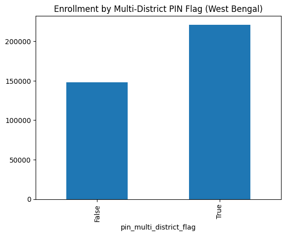

```python
df_West_Bengal.groupby('pin_multi_district_flag')['total_enrollment'].sum().plot(
kind='bar'
)
plt.title('Enrollment by Multi-District PIN Flag (West Bengal)')
plt.show()
```

```python
# Aggregate West Bengal enrollment data at the district level by summing enrollmen
# across different age groups (0–5, 5–17, and 18+).
df_West_Bengal_dist_level = df_West_Bengal_cleaned.groupby('district_clean')[
['age_0_5', 'age_5_17', 'age_18_greater']
].sum()
# Compute total enrollment for each district by adding all age-group enrollm
df_West_Bengal_dist_level['total_enrollment'] = (
df_West_Bengal_dist_level['age_0_5'] +
df_West_Bengal_dist_level['age_5_17'] +
df_West_Bengal_dist_level['age_18_greater']
)
```

```python
df_West_Bengal_dist_level.shape
```

```
(40, 4)
```

```python
df_West_Bengal_dist_level
```

| district_clean | age_0_5 | age_5_17 | age_18_greater | total_enrollment |
| --- | --- | --- | --- | --- |
| 24 Paraganas North | 3177 | 2458 | 512 | 6147 |
| 24 Paraganas South | 364 | 104 | 22 | 490 |
| Alipurduar | 1513 | 1706 | 438 | 3657 |
| Bankura | 8803 | 2073 | 150 | 11026 |
| Bardhaman | 13868 | 3367 | 17 | 17252 |
| Birbhum | 13115 | 2002 | 107 | 15224 |
| Cooch Behar | 9279 | 5272 | 429 | 14980 |
| Dakshin Dinajpur | 5257 | 1059 | 99 | 6415 |
| Darjeeling | 4439 | 2736 | 772 | 7947 |
| Dinajpur Dakshin | 707 | 256 | 34 | 997 |
| Dinajpur Uttar | 6478 | 4859 | 334 | 11671 |
| East Midnapore | 1750 | 315 | 4 | 2069 |
| East Midnapur | 1 | 0 | 0 | 1 |
| Hooghly | 11047 | 3842 | 342 | 15231 |
| Howrah | 9837 | 3961 | 146 | 13944 |
| Jalpaiguri | 5596 | 4398 | 537 | 10531 |
| Jhargram | 726 | 167 | 50 | 943 |
| Kalimpong | 168 | 183 | 153 | 504 |
| Koch Bihar | 2163 | 1090 | 10 | 3263 |
| Kolkata | 4927 | 4557 | 722 | 10206 |
| Malda | 12756 | 4456 | 84 | 17296 |
| Medinipur West | 325 | 300 | 20 | 645 |
| Murshidabad | 30593 | 4290 | 85 | 34968 |
| Nadia | 13096 | 3599 | 840 | 17535 |
| North 24 Parganas | 21205 | 5668 | 1347 | 28220 |
| North Dinajpur | 260 | 78 | 0 | 338 |
| North Twenty Four Parganas | 1202 | 393 | 2 | 1597 |
| Paschim Bardhaman | 856 | 317 | 93 | 1266 |
| Paschim Medinipur | 13984 | 3651 | 150 | 17785 |
| Purba Bardhaman | 2474 | 386 | 128 | 2988 |
| Purba Medinipur | 12760 | 1299 | 57 | 14116 |
| Purulia | 10072 | 3620 | 134 | 13826 |
| South 24 Pargana | 1 | 1 | 0 | 2 |
| South 24 Parganas | 24659 | 8125 | 304 | 33088 |
| South 24 parganas | 2 | 0 | 0 | 2 |
| South Dinajpur | 366 | 68 | 0 | 434 |
| South Twenty Four Parganas | 2931 | 1113 | 4 | 4048 |
| Uttar Dinajpur | 18040 | 8039 | 366 | 26445 |
| West Medinipur | 1 | 1 | 0 | 2 |
| West Midnapore | 1621 | 526 | 3 | 2150 |

```python
# Sorting District with total enrollment
df_West_Bengal_dist_level.sort_values("total_enrollment",ascending=False).reset_index(drop=True)
# df_West_Bengal_dist_level.to_excel('west_bengal_district_level_enrolment.xlsx')
```

|  | age_0_5 | age_5_17 | age_18_greater | total_enrollment |
| --- | --- | --- | --- | --- |
| 0 | 30593 | 4290 | 85 | 34968 |
| 1 | 24659 | 8125 | 304 | 33088 |
| 2 | 21205 | 5668 | 1347 | 28220 |
| 3 | 18040 | 8039 | 366 | 26445 |
| 4 | 13984 | 3651 | 150 | 17785 |
| 5 | 13096 | 3599 | 840 | 17535 |
| 6 | 12756 | 4456 | 84 | 17296 |
| 7 | 13868 | 3367 | 17 | 17252 |
| 8 | 11047 | 3842 | 342 | 15231 |
| 9 | 13115 | 2002 | 107 | 15224 |
| 10 | 9279 | 5272 | 429 | 14980 |
| 11 | 12760 | 1299 | 57 | 14116 |
| 12 | 9837 | 3961 | 146 | 13944 |
| 13 | 10072 | 3620 | 134 | 13826 |
| 14 | 6478 | 4859 | 334 | 11671 |
| 15 | 8803 | 2073 | 150 | 11026 |
| 16 | 5596 | 4398 | 537 | 10531 |
| 17 | 4927 | 4557 | 722 | 10206 |
| 18 | 4439 | 2736 | 772 | 7947 |
| 19 | 5257 | 1059 | 99 | 6415 |
| 20 | 3177 | 2458 | 512 | 6147 |
| 21 | 2931 | 1113 | 4 | 4048 |
| 22 | 1513 | 1706 | 438 | 3657 |
| 23 | 2163 | 1090 | 10 | 3263 |
| 24 | 2474 | 386 | 128 | 2988 |
| 25 | 1621 | 526 | 3 | 2150 |
| 26 | 1750 | 315 | 4 | 2069 |
| 27 | 1202 | 393 | 2 | 1597 |
| 28 | 856 | 317 | 93 | 1266 |
| 29 | 707 | 256 | 34 | 997 |
| 30 | 726 | 167 | 50 | 943 |
| 31 | 325 | 300 | 20 | 645 |
| 32 | 168 | 183 | 153 | 504 |
| 33 | 364 | 104 | 22 | 490 |
| 34 | 366 | 68 | 0 | 434 |
| 35 | 260 | 78 | 0 | 338 |
| 36 | 1 | 1 | 0 | 2 |
| 37 | 2 | 0 | 0 | 2 |
| 38 | 1 | 1 | 0 | 2 |
| 39 | 1 | 0 | 0 | 1 |